# QSCI 381 HW7 Simon Hans Edasi

2023-02-24

**Part 1: Analysis of Variance (ANOVA)**

Wasting time at work. Employers across the U.S. report that most employees admit to wasting time during the workday, defined as spending time at work on non-work related activities. To study this, researchers randomly select four companies in a large city. For each company, they randomly select up to 30 employees and ask each to indicate, anonymous, how many hours in their 8 hour workday are “wasted” by spending time on non-work related activities.

Use data from the waste.csv file, which is available on Canvas (FilesDataset). The “Company” column in the dataset lists the selected companies as A, B, C, or D. The “Hours” column is the number of hours reported by the employees as wasted. Assume the data are normally distributed.

After downloading the dataset and changing your working directory, use the read.csv command to import the dataset:

```r
waste.data <- read.csv("waste.csv", head=TRUE)
attach(waste.data)
```

**(1a)** The researchers want to determine if the number of hours reported by the employees as wasted time differ among the four companies. When testing this in an ANOVA, which variable is the independent variable and which variable is the dependent variable? (2 points)

We are trying to determine if hours wasted is related to the company, i.e. can we predict hours wasted based on the company. So the company is the predictor or independent variable, and hours wasted is the response, or dependent variable.

**(1b)** What are the null and alternative hypotheses? (2 points)

$H_{o}$ = All groups means are the same  
$H_{a}$ = One group mean is different

**(1c)** Test your hypothesis from (1b). Paste your code and output below. (4 points)

```r
waste_ANOVA <- aov(Hours~Company)
summary(waste_ANOVA)
```

```
##             Df Sum Sq Mean Sq F value   Pr(>F)
## Company      3  19.69   6.564   38.25 2.38e-16 ***
## Residuals   96  16.48   0.172
## ---
## Signif. codes:  0 '***' 0.001 '**' 0.01 '*' 0.05 '.' 0.1 ' ' 1
```

**(1d)** When using alpha = 0.01, what is your statistical conclusion and interpretation based on your results in (1c)? (4 points)

Our P-value is far below the alpha value so we reject the null and accept that at least one mean is different. At least one company has more or fewer mean wasted hours than the other companies.

**(1e)** Now, let’s use R/RStudio to make a box-and-whiskers plot of the hours wasted for each company. In a box-and-whiskers plot, the “boxes” for each group represent the IQR, and the solid line through each box is the median. The “whiskers” are the dashed lines below and above each box and represent the range over which approximately 95% of the data are contained. To make a box-and-whiskers plot, use the following command:

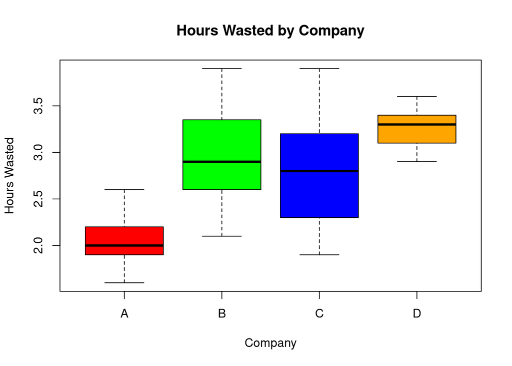

```r
boxplot(Hours ~ Company, xlab="Company", ylab="Hours Wasted", main="Hours Wasted by Company", col=c('Red', 'Green', 'Blue', 'Orange'))
```

**(1f)** Based on your box-and-whiskers plot, which company(ies), if any, is/are most likely to have different numbers of wasted hours? (2 points)

From the boxplot it appears company A has fewer wasted hours and company D has more wasted hours.

**(1g)** Now let’s test your visual assessment from (1f). To do this, we will conduct a post hoc test using Tukey’s HSD test and the default level of alpha, which is 0.05. To run a Tukey’s HSD post hoc test, use the following command:

TukeyHSD(myANOVA)

Paste your results below. (2 points)

```r
TukeyHSD(waste_ANOVA)
```

```
##   Tukey multiple comparisons of means
##     95% family-wise confidence level
##
## Fit: aov(formula = Hours ~ Company)
##
## $Company
##           diff         lwr       upr     p adj
## B-A  0.9157191  0.60566627 1.2257719 0.0000000
## C-A  0.7428205  0.45259545 1.0330456 0.0000000
## D-A  1.2271062  0.90931580 1.5448967 0.0000000
## C-B -0.1728986 -0.47309226 0.1272952 0.4379955
## D-B  0.3113872 -0.01553245 0.6383068 0.0678220
## D-C  0.4842857  0.17610673 0.7924647 0.0004800
```

**(1h)** Examine your output from the TukeyHSD post hoc test. Using alpha=0.05, which companies significantly differ in the number of hours wasted? Which companies do not significantly differ in the number of hours wasted? (5 points)

Company A is significantly different from B C and D, and from the boxplot we know company A has significantly fewer hours wasted. Companies B and C do not significantly differ in hours wasted. Company D is significantly different (more hours wasted) from company C, but not from company B

**Part 2: Correlation**

Sleep in Mammals. Wildlife researchers are interested in the relationship among the amount of time different species of mammals spend sleeping, their maximum life span, and their gestation period. The data are contained in the file sleep.csv, which that is available in Canvas (FilesDatasets). The file contains three columns of data for 62 species of mammals:

TotalSleep = the mean number of hours per day spent sleeping

LifeSpan = the maximum life span in years

Gestation = the mean gestation period in days

After downloading the dataset and changing your working directory, use the read.csv command to import the dataset, and then attach the data to your R/RStudio workspace:

```r
sleep <- read.csv("sleep.csv", head=TRUE)
attach(sleep)
```

**(2a)** Before conducting any analyses, explore the sleep dataset by plotting pair-wise scatterplots using the following command:

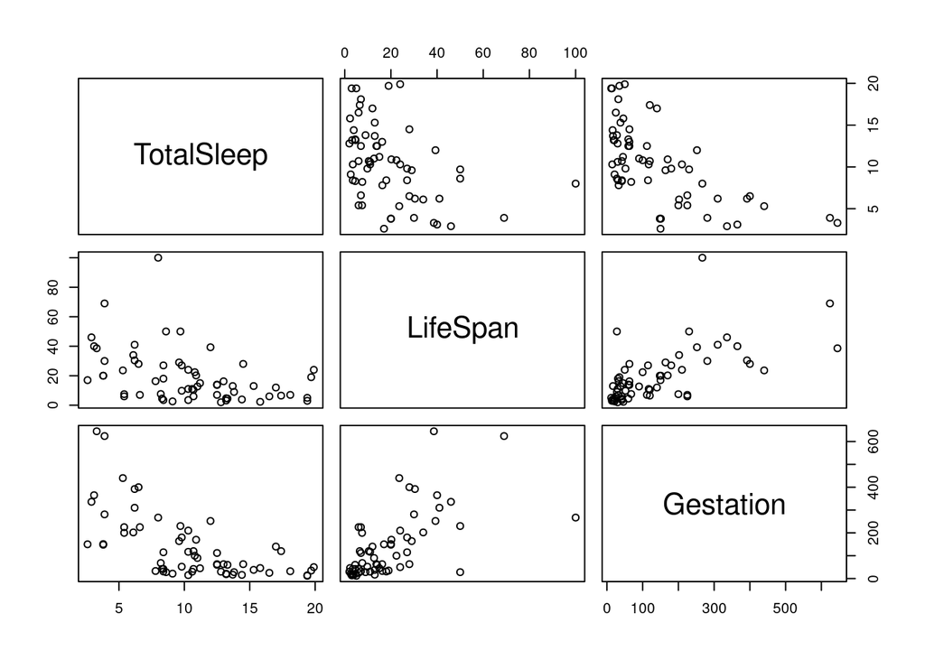

```r
plot(sleep)
```

**(2b)** Examine the pair-wise scatterplot in (2a). Which pair of variables, if any, would you expect to be negatively correlated? Which pair of variables, if any, would you expect to be positively correlated. Justify your response. (3 points)

From the pair-wise scatter plot it would appear that total sleep is negatively correlated with gestation and life span. Gestation and life span appear to be positively correlated.

**(2c)** Consider the correlation coefficient, R, between all possible pairs of the variables within the sleep dataset. Write the null and alternative hypotheses for r in a correlation analysis. (2 points)

**(2d)** Now, conduct a correlation analysis between all possible pairs of the variables within the sleep dataset. Paste your code and output below for each pair of variables. (6 points)

```r
cor.test(TotalSleep, LifeSpan)
```

```
##
##  Pearson's product-moment correlation
##
## data:  TotalSleep and LifeSpan
## t = -3.5867, df = 60, p-value = 0.0006738
## alternative hypothesis: true correlation is not equal to 0
## 95 percent confidence interval:
##  -0.6063181 -0.1903952
## sample estimates:
##        cor
## -0.4201818
```

```r
cor.test(TotalSleep, Gestation)
```

```
##
##  Pearson's product-moment correlation
##
## data:  TotalSleep and Gestation
## t = -6.4044, df = 60, p-value = 2.569e-08
## alternative hypothesis: true correlation is not equal to 0
## 95 percent confidence interval:
##  -0.7651942 -0.4607771
## sample estimates:
##        cor
## -0.6372104
```

```r
cor.test(LifeSpan, Gestation)
```

```
##
##  Pearson's product-moment correlation
##
## data:  LifeSpan and Gestation
## t = 6.3021, df = 60, p-value = 3.823e-08
## alternative hypothesis: true correlation is not equal to 0
## 95 percent confidence interval:
##  0.4526973 0.7609293
## sample estimates:
##       cor
## 0.6311067
```

**(2e)** Using the output from cor.test in (2d), what is the estimate of the correlation coefficient, r, for each pair of variables? (3 points)

r = -0.4201818 $\rightarrow$ TotalSleep and LifeSpan  
r = -0.6372104 $\rightarrow$ TotalSleep and Gestation  
r = 0.6311067 $\rightarrow$ LifeSpan and Gestation

**(2f)** Using alpha = 0.01 and the output from (2d), what is your statistical conclusion and interpretation for each pair of variables? (9 points)

**Part 3: Linear Regression Analysis, Using LifeSpan to predict Gestation**

**(3a)** Use R/RStudio to conduct a linear regression to determine if LifeSpan (independent variable) predicts Gestation (dependent variable) using the dataset from Part 2 (sleep.csv). Fit a linear regression using lm(). Paste your code and output below. (2 points)

```r
model <- lm(Gestation~LifeSpan)
summary(model)
```

```
##
## Call:
## lm(formula = Gestation ~ LifeSpan)
##
## Residuals:
##     Min      1Q  Median      3Q     Max
## -284.28  -54.75  -21.16   33.35  407.30
##
## Coefficients:
##             Estimate Std. Error t value Pr(>|t|)
## (Intercept)  40.5617    21.1708   1.916   0.0601 .
## LifeSpan      5.1072     0.8104   6.302 3.82e-08 ***
## ---
## Signif. codes:  0 '***' 0.001 '**' 0.01 '*' 0.05 '.' 0.1 ' ' 1
##
## Residual standard error: 112.4 on 60 degrees of freedom
## Multiple R-squared:  0.3983, Adjusted R-squared:  0.3883
## F-statistic: 39.72 on 1 and 60 DF,  p-value: 3.823e-08
```

**(3b)** Using your output from (3a), what is the estimate of the slope of the linear regression? What is your statistical conclusion and interpretation of the slope estimate when using alpha = 0.05? (4 points)

**(3c)** Interpret the adjusted R-squared value from your output from (3a). What does this value represent? (4 points)

**(3d)** Use your output from (3a) to write the regression equation. (2 points)

Gestation = 40.5617 + 5.1072 * LifeSpan

**(3e)** Use your regression equation from (3d) to predict the Gestation time in mammals that have a LifeSpan = 7, 32, and 68. (3 points)

```r
g_1 <- 40.5617 + 5.1072 * 7
g_2 <- 40.5617 + 5.1072 * 32
g_3 <- 40.5617 + 5.1072 * 68

print(paste('Gestation for lifespan of 7 years =',  g_1, 'days'))
```

```
## [1] "Gestation for lifespan of 7 years = 76.3121 days"
```

```r
print(paste('Gestation for lifespan of 32 years =',  g_2, 'days'))
```

```
## [1] "Gestation for lifespan of 32 years = 203.9921 days"
```

```r
print(paste('Gestation for lifespan of 68 years =',  g_3, 'days'))
```

```
## [1] "Gestation for lifespan of 68 years = 387.8513 days"
```

**(3f)** Plot the relationship between LifeSpan and Gestation using plot(). Plot LifeSpan on the x-axis and Gestation on the y-axis. Add appropriate axis labels and a main title, and a color of your choice.

After making this plot, you can add a line of best fit based on your linear regression using the abline() function in R/RStudio:

abline(object name)

where object name is the object where your linear regression model was stored when using lm() in (3a). Paste your plot with your line of best fit below. (10 points)

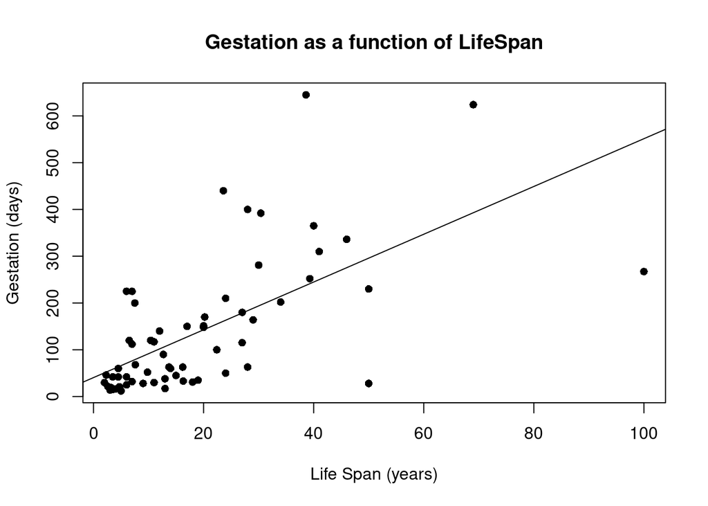

```r
plot(LifeSpan, Gestation, pch = 16, main = 'Gestation as a function of LifeSpan', xlab = 'Life Span (years)', ylab = 'Gestation (days)')
abline(model)
```